# TSIR

Michael Li

13:10 09 August 2016

## Problem

I am trying to figure out why the hybrid TSIR chain binomial is overshooting the estimates (See [poster](https://github.com/wzmli/lunchbox/blob/master/EEID_Final_Mike.pdf). If it doesn’t work, just refresh the page.). Let’s step through it starting from the very beginning.

## Discrete Latent State TSIR Chain Binomial

### Model

_ I didn’t change the parameter names in the code (I will for the paper later… I just want to get over this wall for now and be semi-formal at the same time. So $\alpha = effprop$, r is repMean,$\beta = \textrm{exp}(\frac{-R_{0}}{N})$

The Reed-Frost model is a discrete-time SIR model that assumes recovery one time step after infection. Let $N$ be the population size, $I_{1}$ be the initial number of infectives, $\beta$ be the probability of adequate contact per infective, then the RF model can be written as:

$$S_{1} = N - I_{1}
\\
I_{t} \sim \textrm{Binomial}(\textrm{prob} = 1-(1-\beta)^{I_{t-1}} , \textrm{size}=S_{t-1})
\\
S_{t} = S_{t-1} - I_{t}$$

We modified the RF model as a *latent* binomial process and added an observation process with reporting probability $r$ and assumed $N_{e}$ is from an effective population with an effective proportion $\alpha$ of the upper limit population size *N*. The modified RF model can be written as:

$$N_{e} \sim \textrm{Binomial}(\textrm{prob} = \alpha, \textrm{size}=N)
\\
S_{1} = N_{e} - I_{1}
\\
I_{t} \sim \textrm{Binomial}(\textrm{prob} = 1-(1-\beta)^{I_{t-1}} , \textrm{size}=S_{t-1})
\\
Obs_{t} \sim \textrm{Binomial}(\textrm{prob}=r,\textrm{size}=I_{t})
\\
S_{t} = S_{t-1} - I_{t}$$

## Jags Discrete Latent State Model Results

Using the same parameters as the models in the poster, here are the plots/chains for the discrete latent state chain binomial. *Note* I used stronger priors for the poster and uninformative priors *Beta(1,1)* for $\alpha$ and $r$. I also used the *true* parameters as the initial starting point to see if we can even estimate the parameters given we have a good starting point.

### Parameters

The codes are here (todo: change parameter names to be consistent with write-up):

- [Simulator](https://github.com/wzmli/lunchbox/blob/master/simulators/simulator.CB.R)
- [Bugs script](https://github.com/wzmli/lunchbox/blob/master/dis.B.B.buggen)
- [Parameters](https://github.com/wzmli/lunchbox/blob/master/parameters.CBB.R)
- [Run Jags](https://github.com/wzmli/lunchbox/blob/master/discrete/jags.R)

#### Instructions to reproduce the plots below

- **clone/pull** the latest version of lunchbox
- type **make** (the first time will clone JD’s makestuff)
- type **make dis.jags.fit.Rout** (the second time will simulate and fit the model)

We can see clearly from the traceplots *r* is not mixing well.

```
## Inference for Bugs model at "dis.B.B.buggen", fit using jags,
##  4 chains, each with 1e+05 iterations (first 50000 discarded), n.thin = 50
##  n.sims = 4000 iterations saved
##          mu.vect sd.vect   2.5%    25%    50%    75%  97.5%  Rhat n.eff
## R0         2.075   0.079  1.924  2.023  2.074  2.125  2.239 1.002  2000
## effprop    0.753   0.191  0.292  0.637  0.798  0.906  0.990 1.001  4000
## repMean    0.387   0.144  0.163  0.276  0.370  0.478  0.709 1.068    51
## deviance  71.979   3.773 64.641 69.561 71.778 74.364 79.839 1.006   460
##
## For each parameter, n.eff is a crude measure of effective sample size,
## and Rhat is the potential scale reduction factor (at convergence, Rhat=1).
##
## DIC info (using the rule, pD = var(deviance)/2)
## pD = 7.1 and DIC = 79.1
## DIC is an estimate of expected predictive error (lower deviance is better).
```

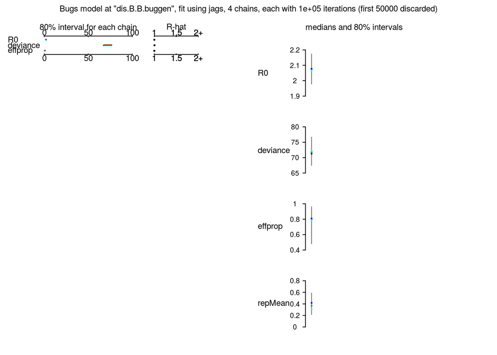

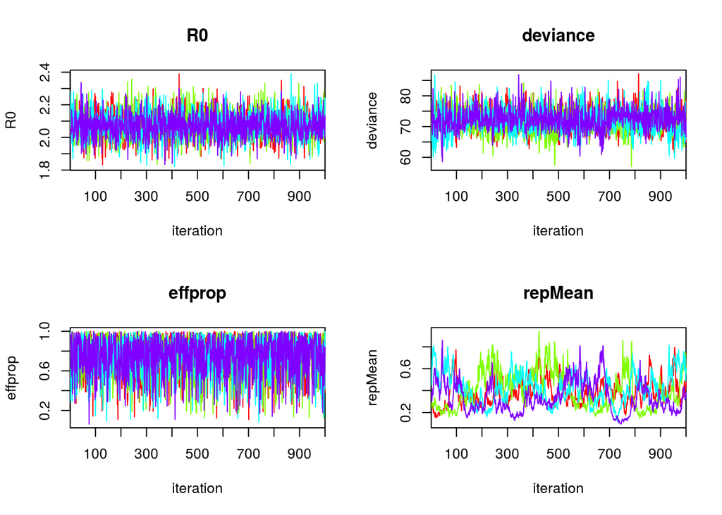

## Hybrid model

The orginal idea of hybridization was to improve the mixing for *r* with some sort of **Scaling trick/ cliff**. We later realized we can take this further and use a more powerful MCMC algorithm (Hamiltonian Monte Carlo). For now, let’s try to figure out the problem in **JAGS**

*… skip all the moment-matching algebra …*

We can rewrite the model (todo: reference equation/system of equations?) as:

$$N_{e} \sim \textrm{Binomial}(\alpha,N)
\\
S_{1} = N_{e} - I_{1}
\\
I_{t} \sim \textrm{Gamma}(\textrm{shape} = \textrm{prob}\times S_{t-1} \times \textrm{rate}, \textrm{rate}= \frac{1}{1-\textrm{prob}})
\\
Obs_{t} \sim \textrm{Poisson}(\textrm{mean}=r \times I_{t})
\\
S_{t} = S_{t-1} - I_{t}$$

## JAGS Hybrid Model Results

The codes are here:

- [Bugs script](https://github.com/wzmli/lunchbox/blob/master/hyb.B.P.buggen)
- [Run Jags](https://github.com/wzmli/lunchbox/blob/master/hybrid/jags.R)

#### Instructions to reproduce the plots below

- type **make hyb.jags.fit.Rout** (given you already did the first two step before)

```
## Inference for Bugs model at "hyb.B.P.buggen", fit using jags,
##  4 chains, each with 1e+05 iterations (first 50000 discarded), n.thin = 50
##  n.sims = 4000 iterations saved
##          mu.vect sd.vect   2.5%    25%    50%    75%  97.5%  Rhat n.eff
## R0         1.939   0.188  1.579  1.808  1.939  2.063  2.323 1.001  4000
## effprop    0.671   0.211  0.249  0.511  0.686  0.851  0.985 1.004  1600
## repprop    0.255   0.131  0.114  0.165  0.216  0.306  0.591 1.004  1200
## deviance  76.788   4.764 69.097 73.417 76.237 79.667 87.385 1.001  4000
##
## For each parameter, n.eff is a crude measure of effective sample size,
## and Rhat is the potential scale reduction factor (at convergence, Rhat=1).
##
## DIC info (using the rule, pD = var(deviance)/2)
## pD = 11.4 and DIC = 88.1
## DIC is an estimate of expected predictive error (lower deviance is better).
```

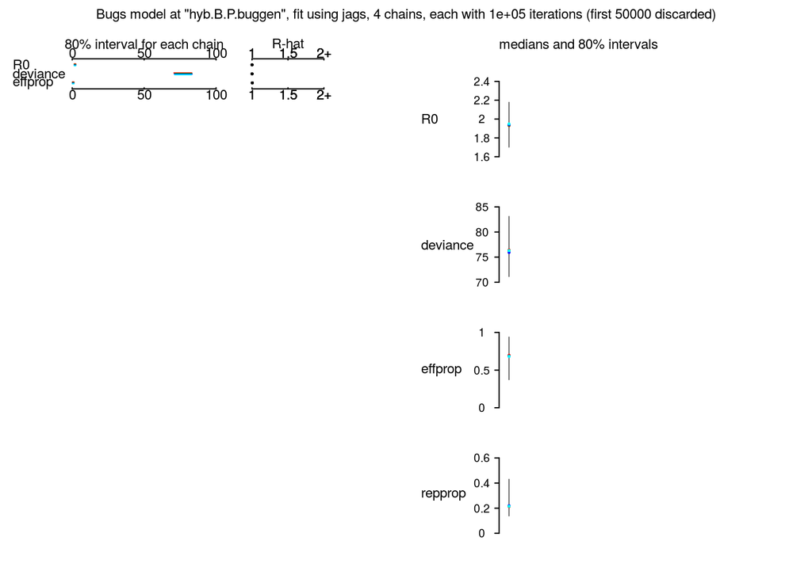

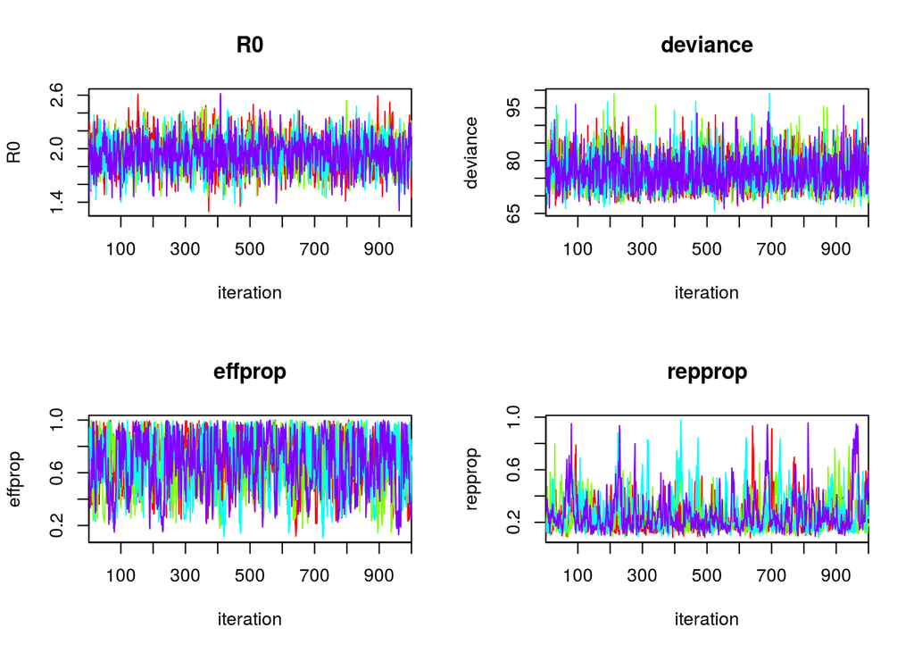